# ROS2

#### Modify the CMakelists.txt

Modify the CMakeLists.txt to compile your C++ node:

Open CMakeLists.txt and add the following lines:

```python
find_package(rclcpp REQUIRED)
find_package(std_msgs REQUIRED)

add_executable(my_node src/my_node.cpp)

ament_target_dependencies(my_node rclcpp std_msgs)

install(TARGETS
  my_node
  DESTINATION lib/${PROJECT_NAME})
```

[figure not shown]

#### Build the Package

Now, return to the root of your workspace and build the package using colcon build.

```python
cd ~/ros2_ws
colcon build
```

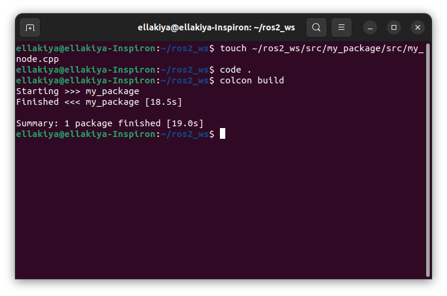

#### Source the Workspace

Source your workspace again so that ROS 2 can find the new package:

```python
source install/setup.bash
```

#### Run the Node

Finally, you can run your new ROS 2 node using the ros2 run command:

```python
ros2 run my_package my_node
```

This will start the node, and you should see output in the terminal every 500ms as the node publishes messages.

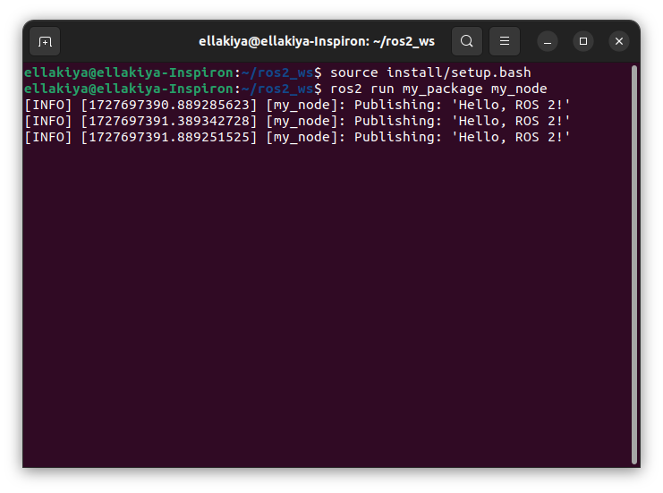

#### 4. Create a Launch File

Create a launch folder in your package:

```python
mkdir ~/ros2_ws/src/my_package/launch
```

Create a new Python-based launch file, my_launch.py, in the launch folder:

```python
touch ~/ros2_ws/src/my_package/launch/my_launch.py
```

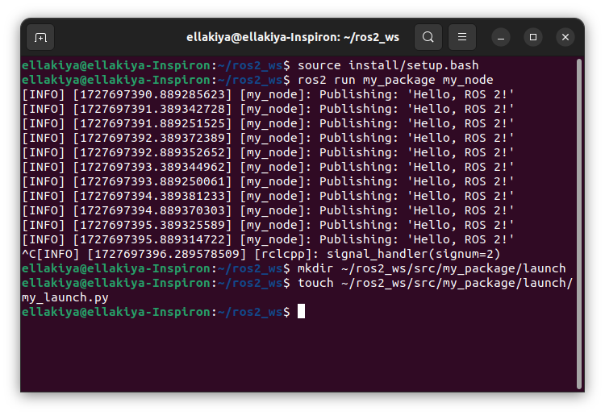

Add the following content to the launch file:

```python
from launch import LaunchDescription
from launch_ros.actions import Node

def generate_launch_description():
    return LaunchDescription([
        Node(
            package='my_package',
            executable='my_node',
            output='screen'
        ),
    ])
```

##### Modify CMakeLists.txt to Include the Launch Directory:

To install the launch files as part of your package, you need to modify the CMakeLists.txt file to ensure the launch files are installed when you build your package.

Add the following lines to install the launch files:

```python
# Find the necessary packages
find_package(ament_cmake REQUIRED)
find_package(rclcpp REQUIRED)

# Install the launch files
install(DIRECTORY launch/
  DESTINATION share/${PROJECT_NAME}/launch
)

# Install executables (if any)
install(TARGETS
  my_node
  DESTINATION lib/${PROJECT_NAME})

# ament package macros
ament_package()
```

[figure not shown]

##### Run the Launch File

To run the node with the launch file:

```python
ros2 launch my_package my_launch.py
```

This will start the node specified in the launch file.

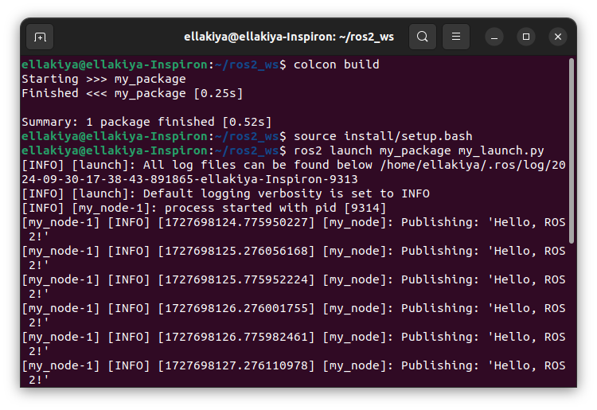

##### Check Node Execution and Logs

Run the node again and check if any error or warning messages appear in the terminal.

```python
ros2 run my_package my_node
```

##### Verify the Topic is Being Published

Use ros2 topic list to verify that the topic is being created. (In another terminal)

```python
ros2 topic list
```

You should see /topic in the list. If the topic doesn’t appear, there might be an issue with how the publisher is being created.

##### Check the Topic Message with ros2 topic echo

Check if messages are being published on the topic:

```python
ros2 topic echo /topic
```

If messages like "Hello, ROS 2!" appear in the terminal, the node is working fine, and the issue could be elsewhere (e.g., with a subscriber node or incorrect topic name in a subscriber).

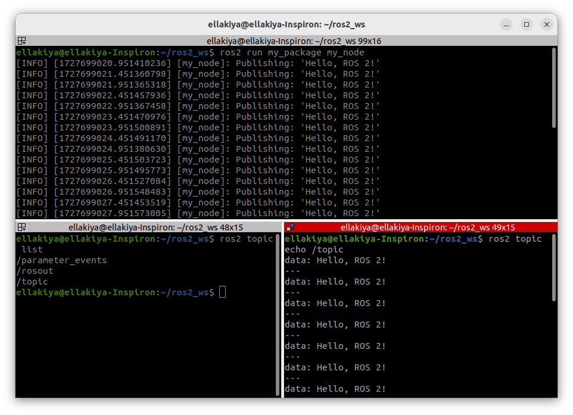

#### Subscriber Node:

write a C++ subscriber node for the publisher node above:

```python
#include <rclcpp/rclcpp.hpp>
#include <std_msgs/msg/string.hpp>

class MySubscriberNode : public rclcpp::Node
{
public:
  MySubscriberNode() : Node("my_subscriber_node")
  {
    // Create a subscription on the same topic "topic" the publisher uses
    subscription_ = this->create_subscription<std_msgs::msg::String>(
        "topic", 10, std::bind(&MySubscriberNode::topic_callback, this, std::placeholders::_1));
  }

private:
  void topic_callback(const std_msgs::msg::String::SharedPtr msg) const
  {
    RCLCPP_INFO(this->get_logger(), "Received: '%s'", msg->data.c_str());
  }

  rclcpp::Subscription<std_msgs::msg::String>::SharedPtr subscription_;
};

int main(int argc, char *argv[])
{
  rclcpp::init(argc, argv);
  rclcpp::spin(std::make_shared<MySubscriberNode>());
  rclcpp::shutdown();
  return 0;
}
```

In this C++ subscriber node:

1. Create_subscription(): Creates a subscriber that listens to the "topic" topic. When a message is received, it calls the topic_callback() function.
2. The message is printed to the console using RCLCPP_INFO().